# RR v HR Rmd

Chase Latour

3/9/2023

# Call in the data

Call in the data from the server. These data are publicly accessible through Project Data Sphere but require a signed data use agreement, so we do not provide them here.

```r
raw_data <- read_sas("/local/projects/DETECTe/data/raw/mCRC_WT/analysis/cohort.sas7bdat")
```

# Describe the participants

Here, we determine how many people we have in each trial. Folks in PRIME received panitumumab as first-line therapy (i.e., first_line = 1) whereas folks in Study 20050181 received panitumumab as second-line therapy (i.e., first_line = 0).

```r
# Get the total number of individuals across the trials

raw_data %>%
  summarize(n_total = n())
```

```
## # A tibble: 1 × 1
##   n_total
##     <int>
## 1     984
```

```r
raw_data %>%
  group_by(first_line) %>%
  summarize(n_by_trial = n())
```

```
## # A tibble: 2 × 2
##   first_line n_by_trial
##        <dbl>      <int>
## 1          0        472
## 2          1        512
```

# Clean the dataset

Here we first check the maximum amount of follow-up in each treatment arm.

```r
# Look at the maximum amount of follow-up in each treatment arm.
raw_data %>%
  group_by(trt) %>%
  summarize(maximum = max(days)) %>%
  kbl() %>%
  kable_styling()
```

| trt | maximum |
| --- | --- |
| 0 | 1310 |
| 1 | 1252 |

The maximum amount of follow-up in the untreated is 1,310 days, while the maximum follow-up in the treated is 1,252. We want the same amount of follow-up, so we limit the follow-up for 1,252 days for each person in the analysis.

```r
# Want to have a uniform amount of follow-up across the treatment groups, particularly for the non-parametric analyses.
mCRC <- raw_data %>%
  mutate(days = ifelse(days > 1252, 1252, days),
         event = ifelse(days > 1252, 0, event)) %>%
  # Calculate years as time frame
  mutate(years = days/365)
```

# Calculate final HR

We use a Cox proportional hazards model to calculate the HR estimate at 1,252 days of follow-up.

**HR = 0.82 (95% CI: 0.71, 0.93)**

```r
cox <- coxph(formula = Surv(days, event) ~ trt, data=mCRC)

summary(cox)
```

```
## Call:
## coxph(formula = Surv(days, event) ~ trt, data = mCRC)
##
##   n= 984, number of events= 861
##
##         coef exp(coef) se(coef)      z Pr(>|z|)
## trt -0.20306   0.81623  0.06828 -2.974  0.00294 **
## ---
## Signif. codes:  0 '***' 0.001 '**' 0.01 '*' 0.05 '.' 0.1 ' ' 1
##
##     exp(coef) exp(-coef) lower .95 upper .95
## trt    0.8162      1.225     0.714    0.9331
##
## Concordance= 0.535  (se = 0.01 )
## Likelihood ratio test= 8.83  on 1 df,   p=0.003
## Wald test            = 8.84  on 1 df,   p=0.003
## Score (logrank) test = 8.88  on 1 df,   p=0.003
```

```r
summary_hr <- as.double(summary(cox)[["coefficients"]][2])
```

# Calculate final RR

We want to calculate the RR at 1,252 days of follow-up for comparison with the HR.

## Function to calculate the RR at a specific point in FUP

This function allows users to calculate the risk ratio at user-specified point in follow-up: `fup_days`.

```r
RR_calc <- function(fup_days, km_model){

  summary_km <- summary(km_model, times = fup_days)

  kmdat <- data.frame(summary_km[c("surv","time","std.err","strata")])

  data <- kmdat %>%
    mutate(r = 1-surv,
           RR = r/lag(r),
           r0= first(r), r1 = last(r),
           se0 = first(std.err), se1 = last(std.err),
           selnrr = sqrt((1/r0)^2 * se0^2 + (1/r1)^2*se1^2),
           LCL = exp(log(RR) - 1.96*selnrr),
           UCL = exp(log(RR) + 1.96*selnrr)) %>%
    filter(RR == last(RR)) %>%
    dplyr::select(c(RR, LCL, UCL)) %>%
    mutate(RR = round(RR, 2),
           LCL = round(LCL, 2),
           UCL = round(UCL, 2))

  return(data)

}
```

## Calculate RR at 1,252 Days

We calculate the RR at 1,252 days here.

```r
# Run the Kaplan-Meier estimator
km <- survfit(Surv(days, event) ~ trt, data=mCRC)

# Pull a summary of the Kaplan-Meier output
summary_km <- summary(km)

#Make a useable database

summary_tibble <- tibble(trt = summary_km$strata,
                    time = summary_km$time, surv = summary_km$surv) %>%
  mutate(time_365 = time / 365,
         risk = 1 - surv,
         trt2 = factor(trt, levels = c(0, 1), labels = c("Chemo Only", "Panitumumab+Chemo"))
         )

# Make the table interpretable
RR_calc(1252, km) %>%
  kbl() %>%
  kable_styling()
```

| RR | LCL | UCL |
| --- | --- | --- |
| 0.99 | 0.96 | 1.02 |

## Calculate RR at different points in follow-up.

We want to plot RR estimates at different points in follow-up. We calculate them here but do not output them. They will be displayed on the survival curve plot.

```r
rr_180 <- RR_calc(180, km) # Calculate the RR at 90 days
rr180 <- as.double(round(rr_180[1,1],2)) # Extract the RR

rr_365 <- RR_calc(365, km) # Calculate the RR at 90 days
rr365 <- as.double(round(rr_365[1,1],2)) # Extract the RR

rr_730 <- RR_calc(730, km)
rr730 <- as.double(round(rr_730[1,1],2))

rr_1095 <- RR_calc(1095, km)
rr1095 <- as.double(round(rr_1095[1,1],2))
```

# Calculate median survival time

Find the first point in follow-up where survial falls at or below 50%

## Panitumumab-Chemotherapy

```r
# Trt = 1
median_p_chemo <- as.double(subset(summary_tibble$time,
                                   summary_tibble$trt == "trt=1" & summary_tibble$surv <= .5)[1])

#Print
#Days
#median_p_chemo
#Years
round(median_p_chemo/365,1)
```

```
## [1] 0.7
```

## Chemotherapy-Only

```r
# Trt = 0
median_chemo <- as.double(subset(summary_tibble$time,
                                 summary_tibble$trt == "trt=0" & summary_tibble$surv <= .5)[1])
#Print
#Days
#median_chemo
#Years
round(median_chemo/365,1)
```

```
## [1] 0.6
```

# Survival Curve

We plot the study’s full survival curve.

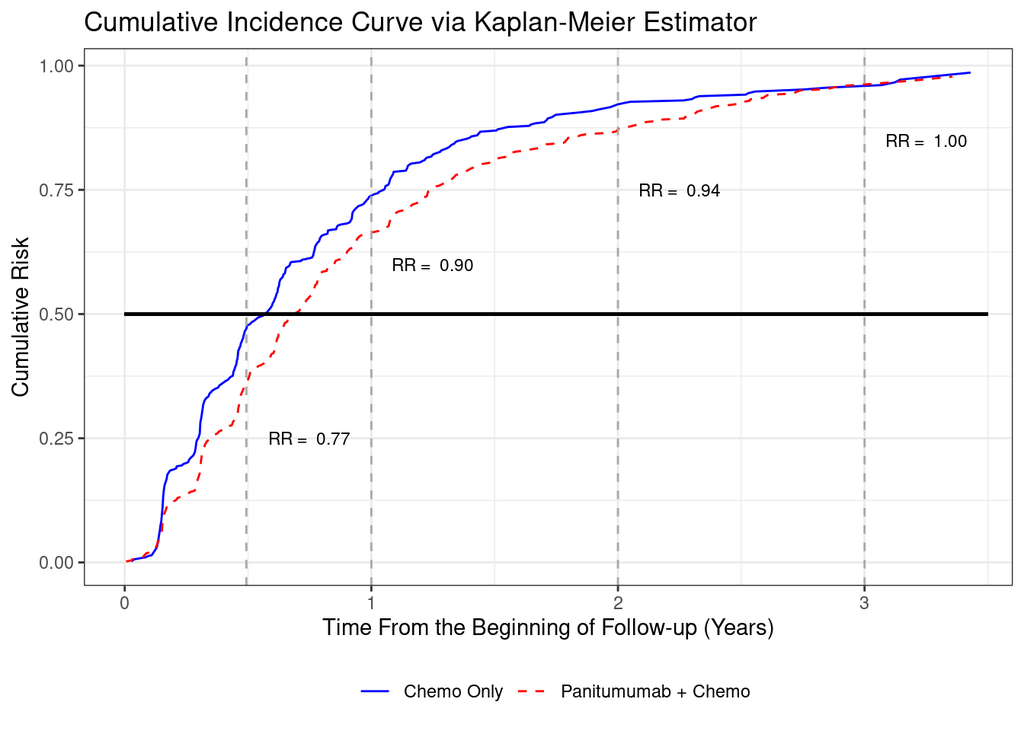

```r
#Make sure that all have the right number of decimal places
rr180_formatted <- sprintf("%.2f", rr180)
rr365_formatted <- sprintf("%.2f", rr365)
rr730_formatted <- sprintf("%.2f", rr730)
rr1095_formatted <- sprintf("%.2f", rr1095)

# For manuscript
#tiff(filename = "Cumulative Incidence_Years.tiff", width = 140, height = 100, units = "mm", res = 600, compression = "lzw")
# For poster
#bitmap("Cumulative Incidence_Poster.tiff", width=14, height=7.5, units="in", type='tifflzw',res=600)
# Extract time points and survival probabilities


summary_tibble %>%
  #Plot
  ggplot(aes(x = time_365, y = risk, color = trt, linetype=trt)) +
    geom_line() +
    labs(
      x = "Time From the Beginning of Follow-up (Years)",
      y = "Cumulative Risk",
      color = "",
      linetype = "",
      title = "Cumulative Incidence Curve via Kaplan-Meier Estimator"
    ) +
  scale_color_manual(values = c("trt=0" = "blue", "trt=1" = "red"),
                     breaks = c("trt=0","trt=1"),
                     labels = c("Chemo Only","Panitumumab + Chemo")) +
  scale_linetype_manual(
    values = c("trt=0" = "solid", "trt=1" = "dashed"),
    breaks = c("trt=0","trt=1"),
    labels = c("Chemo Only","Panitumumab + Chemo")
  ) +
  theme_bw()+
  theme(legend.position = "bottom",  # Move the legend to the bottom
        legend.direction = "horizontal",  # Display the legend items horizontally
        legend.box = "horizontal") +  # Display the legend items in a horizontal box
  geom_vline(xintercept=180/365, lty="dashed", col="darkgrey") +
  geom_vline(xintercept=365/365, lty="dashed", col="darkgrey") +
  geom_vline(xintercept=730/365, lty="dashed", col="darkgrey") +
  geom_vline(xintercept=1095/365, lty="dashed", col="darkgrey") +
  geom_segment(x = 0, xend = 3.5, y = 0.5, yend = 0.5, color = "black",
               lty = "solid", linewidth = 0.6) +
  annotate("text",
           x=c(0.75, 1.25, 2.25, 3.25
               #, 2
               ),
           y=c(0.25, 0.6, 0.75, 0.85
               #, 0.45
               ),
           label = c(paste("RR = ", rr180_formatted),
                     paste("RR = ", rr365_formatted),
                     paste("RR = ", rr730_formatted),
                     paste("RR = ", rr1095_formatted)),
                                                      #paste("Median PFS: Panitumumab-Chemo = ",
                                                       #round(median_p_chemo/365,2),
                                                       #", Chemo = ", round(median_chemo/365, 2))),
           cex = 3) #+
```

```r
  #theme_bw()
#dev.off()  # Close the TIFF file
```

# Plot Kernel-Smoothed Hazard Curves

## Function to Calculate HR at Different FUP

To calculate the HR at different points in follow-up, it is necessary to reset the point at which individuals are administratively censored. This function administratively censors everyone at a user-specified amount of time: `fup_days`.

```r
HR_FUP <- function(data, fup_days){

  data2 <- raw_data %>%
    mutate(event = ifelse(days > fup_days, 0, event),
           days = ifelse(days > fup_days, fup_days, days))

  cox2 <- coxph(formula = Surv(days,event) ~ trt, data=data2, ties = "efron")


  return(as.double(summary(cox2)$coefficients[1,2]))

}
```

## Calculate HRs at Different FUPs

```r
# Calculate and reformat

hr180 <- round(HR_FUP(raw_data,180),2)
hr180 <- sprintf("%.2f", hr180)

hr365 <- round(HR_FUP(raw_data,365),2)
hr365 <- sprintf("%.2f", hr365)

hr730 <- round(HR_FUP(raw_data,730),2)
hr730 <- sprintf("%.2f", hr730)

hr1095 <- round(HR_FUP(raw_data,1095),2)
hr1095 <- sprintf("%.2f", hr1095)
```

## Create Plot

Calculate the kernel-smoothed objects.

```r
#Transform this so that it's years
mCRC$years <- mCRC$days/365

trt0.mCRC <- muhaz(mCRC$years, mCRC$event,subset = mCRC$trt == 0)

trt1.mCRC <- muhaz(mCRC$years, mCRC$event,subset = mCRC$trt == 1)

#OLD CODE -- Days as the time unit

#trt0.mCRC <- muhaz(mCRC$days, mCRC$event,subset = mCRC$trt == 0)

#trt1.mCRC <- muhaz(mCRC$days, mCRC$event,subset = mCRC$trt == 1)
```

Calculate the approximately the HRs at each time point via the non-parametric estimates.

```r
#Determine which location on the vector of time points is closest to the estimates of interest

## TRT = Chemo Only
est180_0 <- max(which(trt0.mCRC$est.grid <= 180/365))
est365_0 <- max(which(trt0.mCRC$est.grid <= 365/365))
est730_0 <- max(which(trt0.mCRC$est.grid <= 730/365))
est1095_0 <- max(which(trt0.mCRC$est.grid <= 1095/365))
## TRT = Panitumumab+Chemo
est180_1 <- max(which(trt1.mCRC$est.grid <= 180/365))
est365_1 <- max(which(trt1.mCRC$est.grid <= 365/365))
est730_1 <- max(which(trt1.mCRC$est.grid <= 730/365))
est1095_1 <- max(which(trt1.mCRC$est.grid <= 1095/365))

# Get the Hazards at that point

## Trt = Chemo Only
h180_0 <- trt0.mCRC$haz.est[est180_0]
h365_0 <- trt0.mCRC$haz.est[est365_0]
h730_0 <- trt0.mCRC$haz.est[est730_0]
h1095_0 <- trt0.mCRC$haz.est[est1095_0]
## Trt = Chemo + Panitumumab
h180_1 <- trt1.mCRC$haz.est[est180_1]
h365_1 <- trt1.mCRC$haz.est[est365_1]
h730_1 <- trt1.mCRC$haz.est[est730_1]
h1095_1 <- trt1.mCRC$haz.est[est1095_1]

# Finally, the kernel-smothed HRs
h180 <- h180_1/h180_0
h365 <- h365_1/h365_0
h730 <- h730_1/h730_0
h1095 <- h1095_1/h1095_0
```

This provides a non-parametric estimate of the hazard rate curves in the two groups.

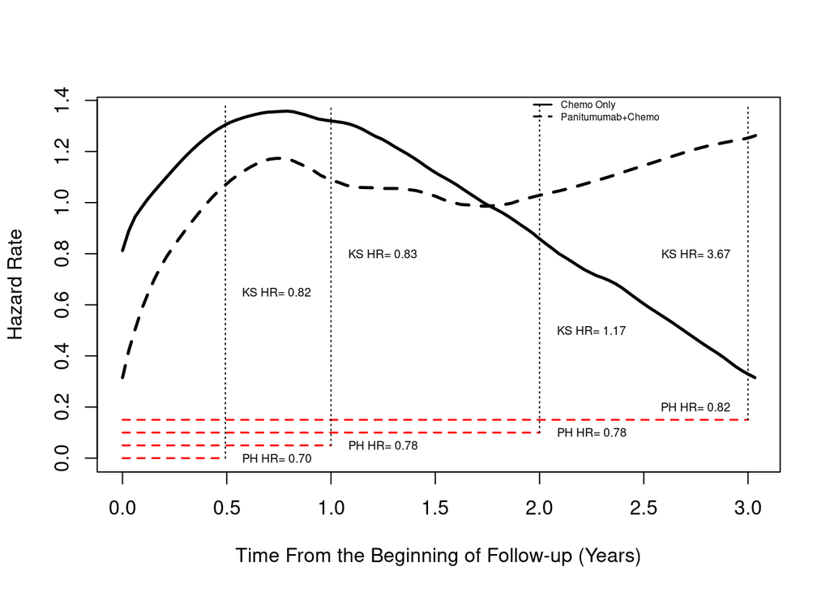

```r
# For manuscript
#bitmap("KS Hazard Curves_Years.tiff",width=140, height=100, units='mm',type='tifflzw',res=600)
# For poster
#bitmap("KS Hazard Curves_Poster.tiff", width=14, height=6.5, units='in', type='tifflzw',res=600)

#tiff(filename = "KS Hazard Curves_Years.tiff", width = 140, height = 100, units = "mm", res = 600, compression = "lzw")
plot(trt0.mCRC,
     xlab = "Time From the Beginning of Follow-up (Years)", # Adjust x-axis label
     lwd = 2.5,
     cex = 1,
     cex.axis = 1,
     cex.lab = 1 #,
     #xlim = c(0, 3.5) # Adjust x-axis limits to match the new scale
)
lines(trt1.mCRC, lty="dashed", lwd=2.5)
segments(x0=0,x1=180/365, y0= 0.00, y1=0.00, lwd=1.5, lty="dashed", col="red")
segments(x0=0,x1=365/365, y0= 0.05, y1=0.05, lwd=1.5, lty="dashed", col="red")
segments(x0=0, x1=730/365, y0=0.10, y1 = 0.10, lwd=1.5, lty="dashed", col="red")
segments(x0=0, x1=1095/365, y0=0.15, y1=0.15, lwd=1.5, lty="dashed", col="red")
legend(1.93, 1.43, c("Chemo Only","Panitumumab+Chemo"),
       lty = c("solid","dashed"),
       cex = 0.5,
       lwd=1.5,
       bty = "n")
text(x=0.74, y=0.0, paste("PH HR=", hr180), cex = 0.6)
text(x=1.25, y=0.05, paste("PH HR=", hr365), cex = 0.6)
text(x=2.25, y= 0.1, paste("PH HR=",hr730), cex = 0.6)
text(x=2.75, y= 0.20, paste("PH HR=", hr1095), cex = 0.6)
segments(x0=180/365, x1=180/365, y0=0.0, y1=1.38, lty="dotted")
segments(x0=365/365, x1=365/365, y0=0.05, y1=1.38, lty="dotted")
segments(x0=730/365, x1=730/365, y0=0.10, y1=1.38, lty="dotted")
segments(x0=1095/365, x1=1095/365, y0=0.15, y1=1.38, lty="dotted")
text(x = 0.74, y=0.65, paste("KS HR=", round(h180,2)), cex = 0.6)
text(x = 1.25, y=0.8, paste("KS HR=", round(h365,2)), cex = 0.6)
text(x = 2.25, y=0.5, paste("KS HR=", round(h730,2)), cex = 0.6)
text(x = 2.75, 0.8, paste("KS HR=", round(h1095,2)), cex = 0.6) # previously: x=1052
```

```r
#dev.off()
```

# Plot Log of Cumualtive Hazards

Plotting the log of the cumualtive hazards is another tool for assessing the PH assumption. If the lines are relatively parallel, then we would say that they are proportional. We see here again that the lines cross.

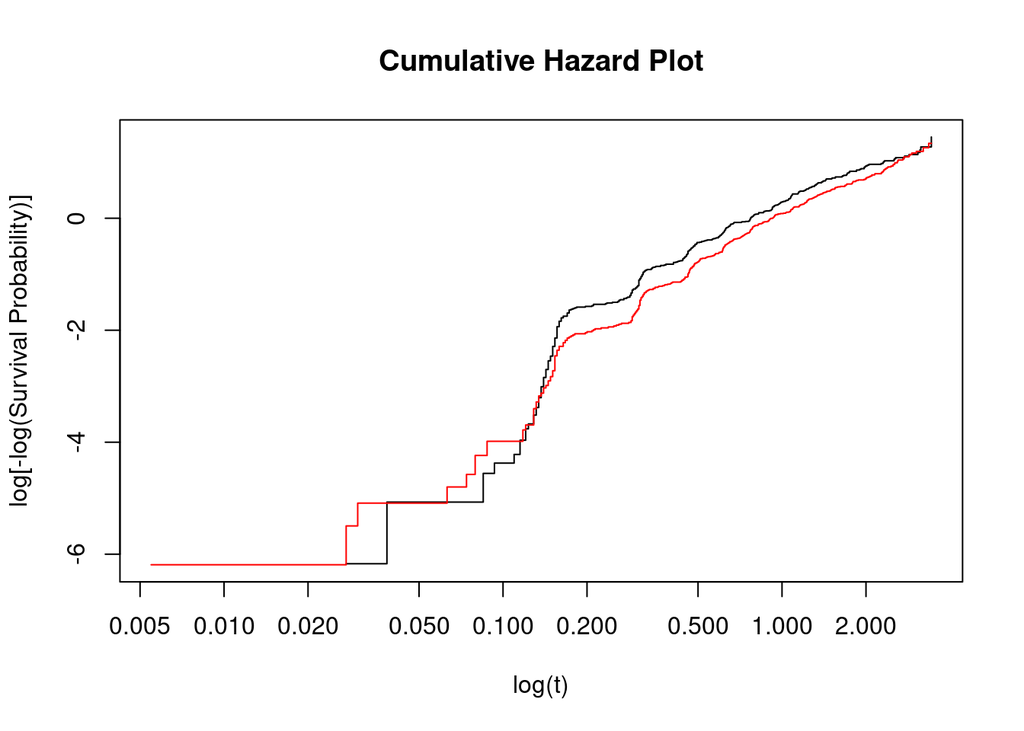

```r
## For manuscript
# bitmap("Plot of the Log Cumulative Hazards.tiff",width=140, height=100, units='mm',type='tifflzw',res=600)

#pdf("Plot_of_the_Log_Cumulative_Hazards.pdf")

plot(survfit(Surv(years,event) ~ trt, data = mCRC),
     col=c("black", "red"),
     fun="cloglog",
     main = "Cumulative Hazard Plot",
     xlab = "log(t)",
     ylab = "log[-log(Survival Probability)]")
```

```r
#dev.off()
```

# Interaction Term in Cox Model

Model with interaction term between treatment and continuous time.

```r
continuous <- coxph(Surv(years,event) ~ trt, # Previously days
                    data = mCRC,
                    ties = "efron")
continuous2 <- cox.zph(continuous, transform = "identity")

# Output results from continuous2 - This provides the p-value for the test of non-proportional hazards.
continuous2
```

```
##        chisq df     p
## trt     4.43  1 0.035
## GLOBAL  4.43  1 0.035
```

```r
# Grab the y-axis labels from the upcoming plot so that we can exponentiate and plot accordingly

plot(continuous2[1],
     ylim=c(-1.1, 1.1),
     xlab = "Time from Start of Follow-up (Days)",
     ylab = "Natural Log Transformed Hazard Ratio",
     #cex = 1.3,
     cex = 2,
     #cex.axis = 1.3,
     cex.axis = 2,
     #cex.lab = 1.3,
     cex.lab = 1.5,
     lwd = 2.5
     )

y_labels <- axis(2, at = NULL, las = 1)
```

[output not shown]

```r
exp_labels <- round(exp(y_labels),1)
```

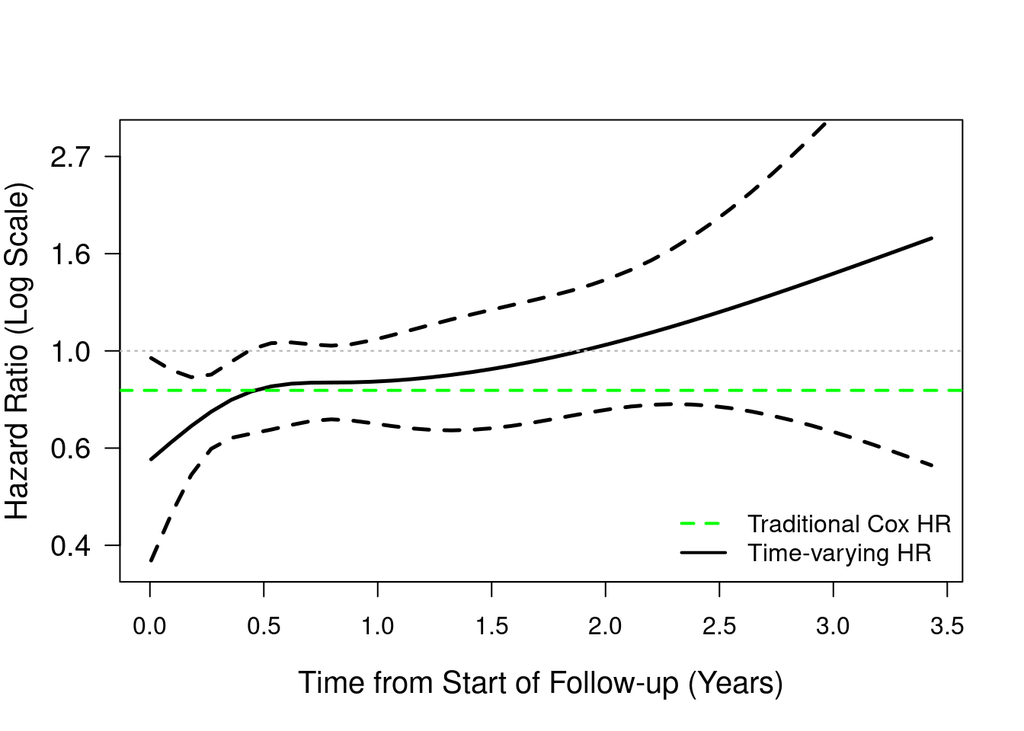

```r
# Plot the time-varying coefficient for treatment

# For manuscript
#bitmap("HR with Continuous Time_Years.tiff",width=140, height=100, units='mm',type='tifflzw',res=600)
# For poster
#bitmap("HRs with Continuous Time_Poster.tiff", width=14, height=7.5, units='in', type='tifflzw',res=600)

#tiff(filename = "HR with Continuous Time_Years.tiff", width = 140, height = 100, units = "mm", res = 600, compression = "lzw")

plot(continuous2[1],
     ylim=c(-1.1, 1.1),
     xlab = "Time from Start of Follow-up (Years)",
     ylab = "Hazard Ratio (Log Scale)",
     #cex = 1.3,
     cex = 1,
     #cex.axis = 1.3,
     cex.axis = 1,
     #cex.lab = 1.3,
     cex.lab = 1.25,
     lwd = 2.5,
     yaxt = "n"
     )
axis(2, at = y_labels, labels = format(exp_labels, scientific = FALSE), las = 1, cex.axis = 1.2)
abline(0,0, lty=3, lwd=1.25, col="grey")
abline(h=log(summary_hr), lwd=2, lty=2, col="green") # previously had col=3
legend("bottomright",
       legend=c("Traditional Cox HR",
                "Time-varying HR"),
       lty=c(2,1), col=c("green",1), lwd=c(2,2),
       cex=1,
       bty = "n")
```

```r
#dev.off()
```

## Restricted Mean Survival Time

Here, we find the following:

**Trt 1:** 344.6 (318.4, 370.8) Days

**Trt 0:** 289.4 (264.8, 314.0) Days

**Difference:** 55.2 (19.2, 91.1) Days

```r
rmst2(mCRC$days, mCRC$event, mCRC$trt, tau = 1095)
```

```
##
## The truncation time: tau = 1095  was specified.
##
## Restricted Mean Survival Time (RMST) by arm
##                 Est.     se lower .95 upper .95
## RMST (arm=1) 344.617 13.366   318.420   370.814
## RMST (arm=0) 289.438 12.547   264.847   314.030
##
##
## Restricted Mean Time Lost (RMTL) by arm
##                 Est.     se lower .95 upper .95
## RMTL (arm=1) 750.383 13.366   724.186   776.580
## RMTL (arm=0) 805.562 12.547   780.970   830.153
##
##
## Between-group contrast
##                        Est. lower .95 upper .95     p
## RMST (arm=1)-(arm=0) 55.179    19.248    91.110 0.003
## RMST (arm=1)/(arm=0)  1.191     1.062     1.334 0.003
## RMTL (arm=1)/(arm=0)  0.932     0.889     0.976 0.003
```

```r
## Trt 1: 344.6 (318.4, 370.8)
## TRT 0: 289.4 (264.8, 314.0)

## Difference: 55.2 (19.2, 91.1)
```

## Events Over Time

```r
mCRC %>%
  mutate(year_interval = cut(years, breaks = seq(0, ceiling(max(years)), by = 0.25), labels = FALSE),
         year_interval_max = year_interval*0.25) %>%
  group_by(trt, year_interval_max) %>%
  summarize(n_event = sum(event == 1),
            .groups = 'drop') %>%
  pivot_wider(names_from = trt,
              values_from = n_event) %>%
  kbl() %>%
  kable_styling()
```

| year_interval_max | 0 | 1 |
| --- | --- | --- |
| 0.25 | 95 | 66 |
| 0.50 | 128 | 110 |
| 0.75 | 60 | 77 |
| 1.00 | 54 | 58 |
| 1.25 | 35 | 39 |
| 1.50 | 20 | 23 |
| 1.75 | 14 | 13 |
| 2.00 | 8 | 10 |
| 2.25 | 2 | 9 |
| 2.50 | 4 | 12 |
| 2.75 | 3 | 9 |
| 3.00 | 2 | 3 |
| 3.25 | 3 | 2 |
| 3.50 | 1 | 1 |
| NA | 0 | 0 |